# Fase1_report

Ana Filipa Moreira, Diana Oliveira, Márcia Silva e Rodolfo Ferreira

2026-03-30

## Estrutura da análise

A análise será organizada em diferentes scripts:

- 01_load_data.R — carregamento dos dados
- 02_preprocessing_clinical.R — limpeza dos dados clínicos
- 03_preprocessing_expression.R — preparação da matriz de expressão
- 04_merge_data.R — integração dos dados
- 05_exploratory_analysis.R — exploração inicial
- 06_statistical_analysis.R — análise estatística e expressão diferencial

## Introdução

Este trabalho tem como objetivo a análise de um conjunto de dados de expressão génica no contexto do adenocarcinoma do pulmão (Lung Adenocarcinoma, LUAD), utilizando R e ferramentas adequadas para análise de dados biológicos.

O conjunto de dados selecionado foi obtido a partir do cBioPortal, correspondendo ao estudo **Lung Adenocarcinoma (TCGA PanCancer Atlas)**. Este estudo inclui informação clínica dos pacientes, informação ao nível da amostra tumoral e dados de expressão génica obtidos por RNA-seq.

## Origem e relevância dos dados

Os dados utilizados neste trabalho foram obtidos do projeto The Cancer Genome Atlas (TCGA), que disponibiliza informação clínica e molecular de diversos tipos de cancro. Neste estudo, foram analisados dados de expressão génica e variáveis clínicas de pacientes com carcinoma pulmonar de não pequenas células (LUAD).

A integração destes dados permite investigar diferenças biológicas entre grupos de pacientes, nomeadamente entre indivíduos jovens e idosos, contribuindo para uma melhor compreensão da progressão da doença e apoiando abordagens de medicina de precisão.

Foram utilizados três ficheiros principais:

- data_clinical_patient.txt: informação clínica ao nível do paciente
- data_clinical_sample.txt: informação ao nível da amostra tumoral
- data_mrna_seq_v2_rsem.txt: dados de expressão genética

```r
source("../scripts/01_load_data.R")
```

De forma preliminar, os dados carregados incluem:

```r
dim(clinical_patient)
```

```
## [1] 566  38
```

```r
dim(clinical_sample)
```

```
## [1] 566  19
```

```r
dim(expr)
```

```
## [1] 20531   512
```

## 1. Variáveis Identificadoras

Incluem identificadores únicos das amostras e dos pacientes:

- `SAMPLE_ID` – identificador da amostra (ex: TCGA-05-4244-01)
- `PATIENT_ID` – identificador do paciente (ex: TCGA-05-4244)

Estas variáveis são do tipo **character** e são utilizadas para integração e rastreabilidade dos dados.

## 2. Variáveis Clínicas e Categóricas

Incluem informação relacionada com o tipo de cancro e características da amostra:

- `SAMPLE_TYPE` – indica o tipo de amostra (ex: tumor primário)
- `TISSUE_SOURCE_SITE` – origem institucional da amostra
- `TISSUE_SOURCE_SITE_CODE` – código associado ao local de recolha
- `TUMOR_TISSUE_SITE` – local anatómico do tumor (ex: pulmão)
- `TISSUE_PROSPECTIVE_COLLECTION_INDICATOR` – indica se a amostra foi recolhida de forma prospetiva
- `TISSUE_RETROSPECTIVE_COLLECTION_INDICATOR` – indica se a amostra foi recolhida retrospectivamente

Estas variáveis são maioritariamente do tipo **character**, representando categorias qualitativas.

Adicionalmente, algumas variáveis apresentam valores em falta, como por exemplo:

- `GRADE` – grau de diferenciação tumoral (variável com valores NA no dataset)

## 3. Variáveis Numéricas Clínicas

Estas variáveis são do tipo **numérico contínuo** (ou inteiro, no caso do ANEUPLOIDY_SCORE) e permitem caracterizar propriedades genómicas e moleculares das amostras.

# 5. Preprocessamento dos dados clínicos

```r
source("../scripts/02_preprocessing_clinical.R")
```

```
## Dimensão do dataset clinical_patient limpo: 566 13
## Dimensão do dataset clinical_sample limpo: 566 5
```

Nesta etapa foi realizada a limpeza e preparação dos dados clínicos e das amostras. Inicialmente, foram selecionadas apenas as variáveis relevantes para a análise, incluindo características demográficas, estádios tumorais e métricas associadas à sobrevivência e carga tumoral .

De seguida, valores vazios foram convertidos em valores ausentes (NA), e foram removidas entradas sem identificadores válidos de paciente ou amostra, garantindo a consistência dos dados. As variáveis numéricas foram convertidas para o formato adequado, permitindo a sua utilização em análises estatísticas.

Foi também efetuada a limpeza das variáveis de estado (como sobrevivência e progressão), removendo prefixos desnecessários, e as variáveis categóricas foram convertidas para o tipo factor, facilitando a sua utilização em modelos e visualizações.

Por fim, foram realizadas verificações básicas da estrutura dos dados, incluindo dimensões e distribuições das principais variáveis, assegurando a qualidade do dataset antes das etapas seguintes.

# 6. Preparação da matriz de expressão

```r
source("../scripts/03_preprocessing_expression.R")
```

```
## Coluna de genes assumida: Hugo_Symbol
## Número de colunas identificadas como amostras: 510
## Dimensão da matriz numérica: 20531 510
## Após remover genes sem ID: 20518 510
## Após remover genes duplicados: 20511 510
## Número total de NA na matriz: 0
## Após remover genes com NA: 20511 510
## Após filtrar genes pouco expressos: 18411 510
##
## Resumo dos valores da matriz filtrada:
##      Min.   1st Qu.    Median      Mean   3rd Qu.      Max.
## 0.000e+00 2.796e+01 2.912e+02 1.080e+03 9.529e+02 1.433e+06
##
## Resumo dos valores da matriz log2:
##    Min. 1st Qu.  Median    Mean 3rd Qu.    Max.
##   0.000   4.856   8.191   7.262   9.898  20.450
##
## Resumo das medianas por amostra:
##    Min. 1st Qu.  Median    Mean 3rd Qu.    Max.
##   7.731   8.097   8.198   8.183   8.283   8.480
##
## Resumo das médias por amostra:
##    Min. 1st Qu.  Median    Mean 3rd Qu.    Max.
##   6.775   7.153   7.265   7.262   7.381   7.648
```

Nesta etapa foi realizada a preparação da matriz de expressão génica para análise. Inicialmente, foi identificada a coluna contendo os identificadores dos genes e selecionadas apenas as colunas correspondentes às amostras, excluindo possíveis colunas de anotação .

De seguida, os dados foram convertidos para formato numérico e organizados numa matriz com genes nas linhas e amostras nas colunas. Foram removidos genes sem identificador válido e duplicados, garantindo a consistência da matriz.

Posteriormente, foram eliminados genes com valores em falta (NA), e aplicada uma filtragem para remover genes pouco expressos, mantendo apenas aqueles com expressão relevante em pelo menos 10% das amostras.

Por fim, foi aplicada uma transformação logarítmica (log2), com o objetivo de estabilizar a variância dos dados e facilitar análises exploratórias, como PCA e visualizações. Foram ainda realizadas verificações descritivas para avaliar a distribuição dos valores e a consistência entre amostras.

# 7. Integração dos dados

```r
source("../scripts/04_merge_data.R")
```

```
## Número de amostras em comum: 510
## Alinhamento correto entre expressão e clínico: TRUE
## Dimensão da matriz de expressão final: 20511 510
## Dimensão do dataset clínico final: 510 17
```

Nesta etapa foi realizada a integração dos dados clínicos e da matriz de expressão génica. Inicialmente, os dados clínicos ao nível do paciente e da amostra foram combinados com base no identificador do paciente (PATIENT_ID), criando um dataset clínico unificado .

De seguida, os identificadores das amostras na matriz de expressão foram ajustados para garantir consistência de formato, permitindo a correspondência com os identificadores presentes nos dados clínicos. Foram então identificadas as amostras comuns entre os dois datasets.

A matriz de expressão génica e o dataset clínico foram filtrados de forma a manter apenas essas amostras em comum. Posteriormente, foi assegurada a correta correspondência entre ambos através do alinhamento da ordem das amostras.

Por fim, foram realizadas verificações de consistência, garantindo que os identificadores das amostras coincidiam entre os dois datasets e confirmando as dimensões finais dos dados integrados, prontos para análise.

## Exploração Estatistica

```r
source("../scripts/aa.R")
```

```
## Dimensão do dataset clínico final: 510 17
## Dimensão da matriz de expressão final: 20511 510
##
##    STAGE I   STAGE IA   STAGE IB   STAGE II  STAGE IIA  STAGE IIB STAGE IIIA
##          5        132        138          1         52         70         72
## STAGE IIIB   STAGE IV       <NA>
##         11         27          2
```

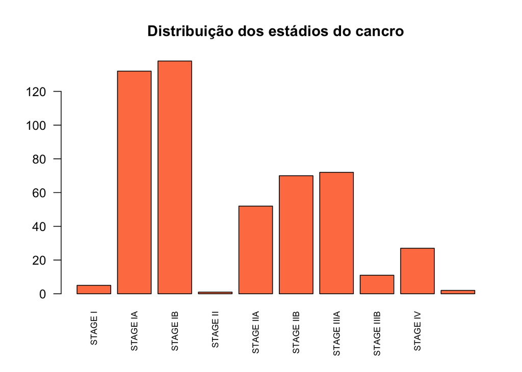

```
##
## Female   Male
##    274    236
```

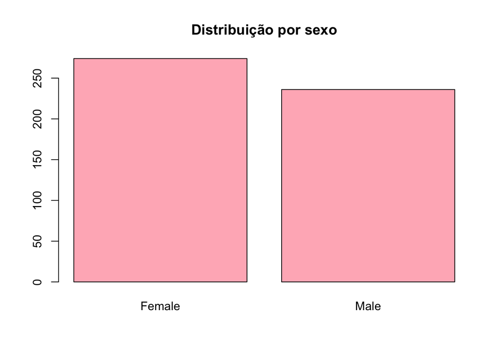

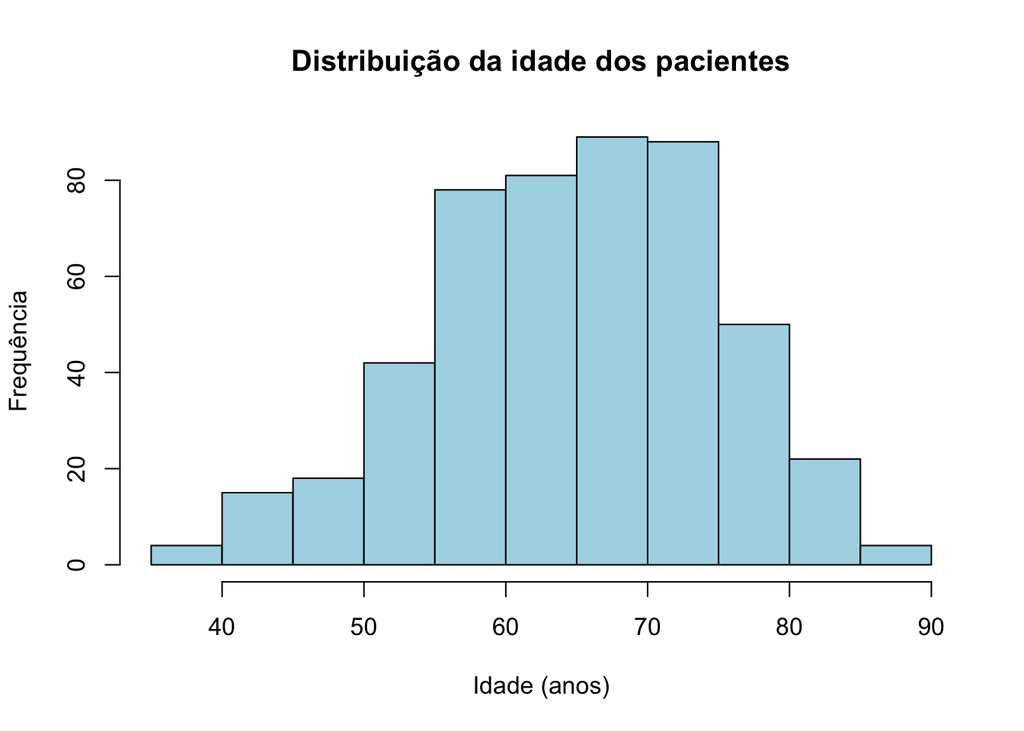

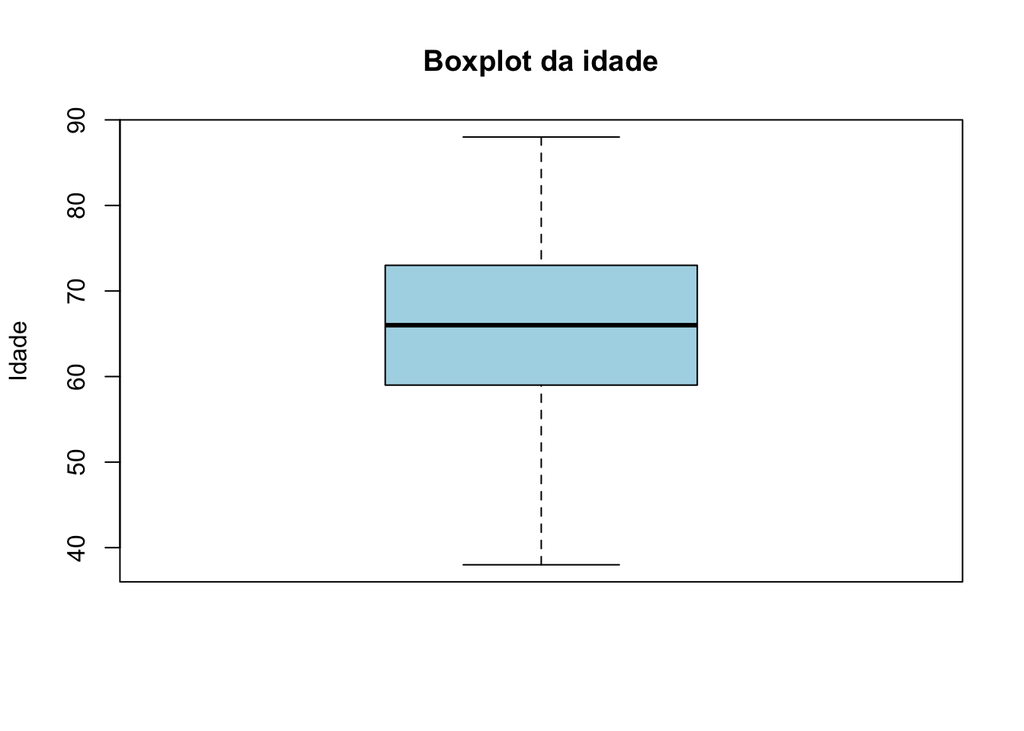

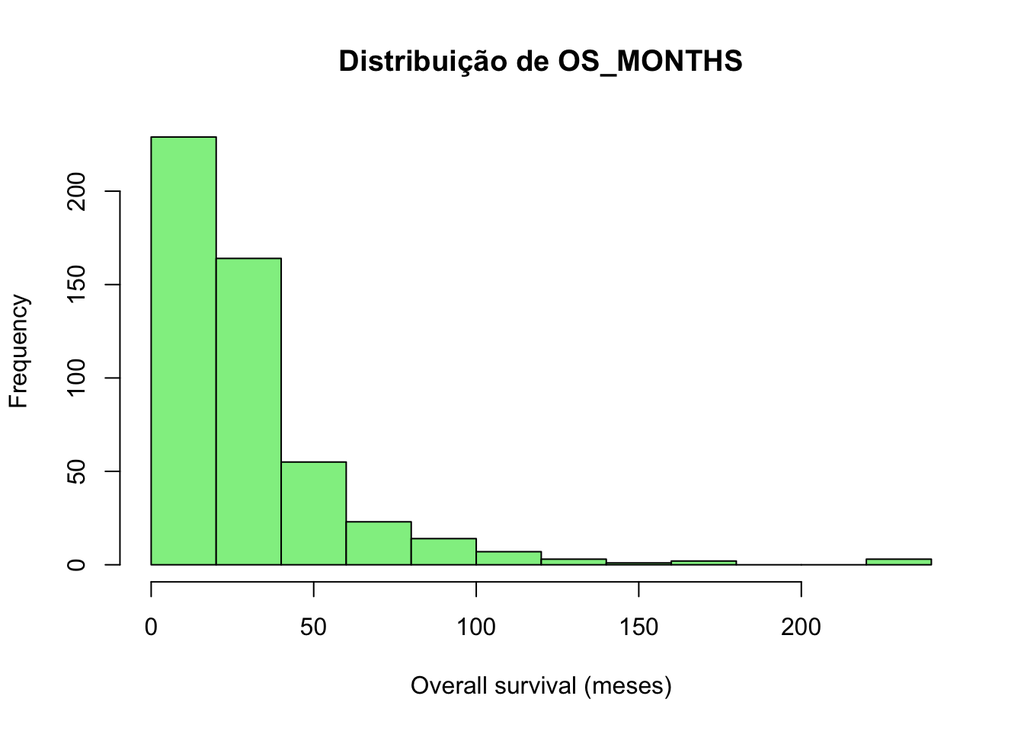

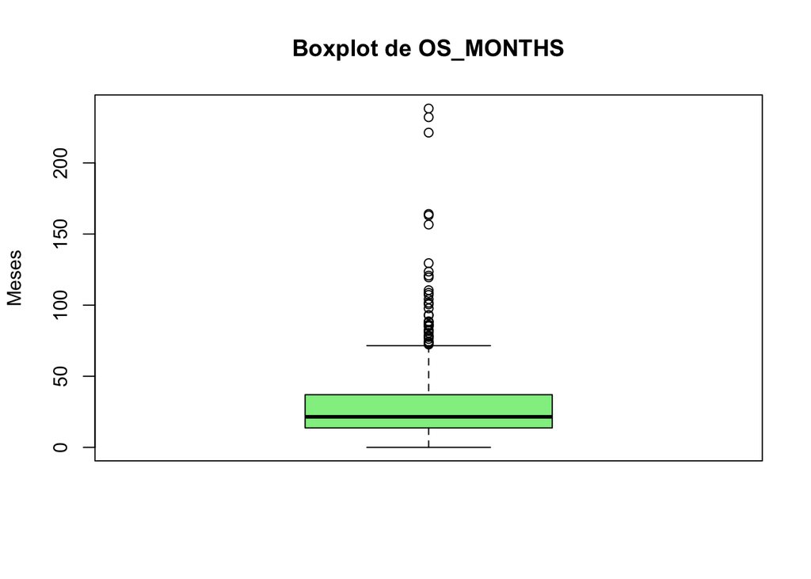

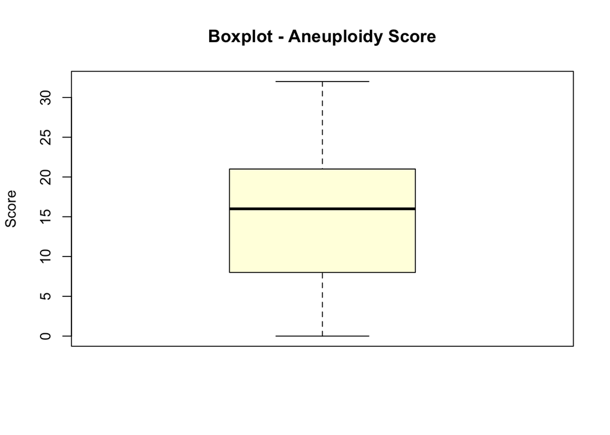

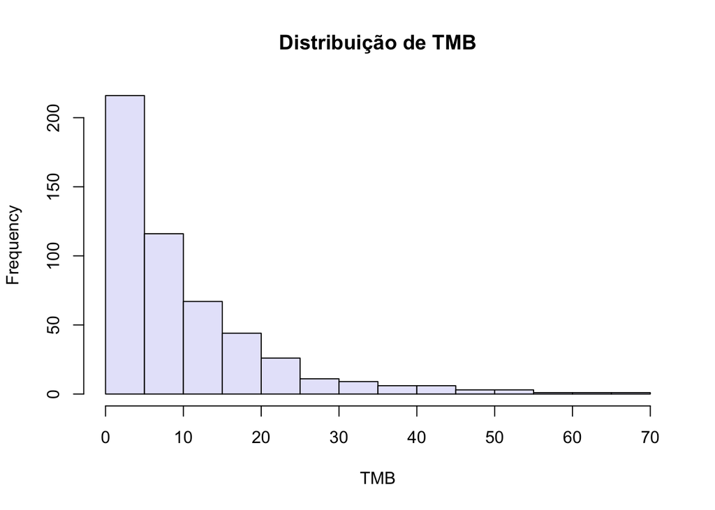

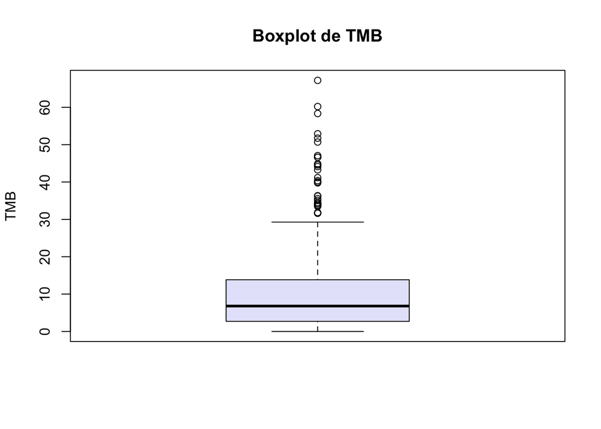

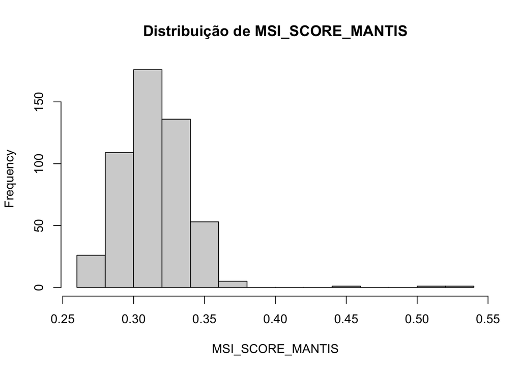

```
## Dimensão da matriz usada para PCA: 5043 510
```

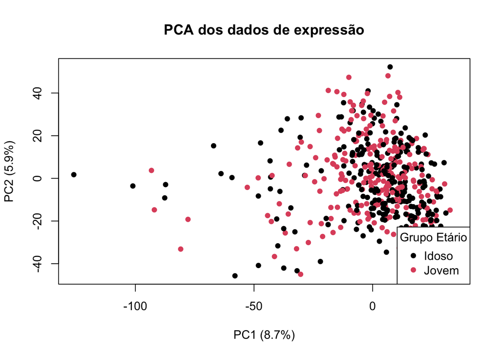

Observa-se uma maior predominância de pacientes nos estádios iniciais (IA e IB), enquanto os estádios mais avançados apresentam menor representação. Esta distribuição sugere um possível desequilíbrio no dataset, o que deve ser considerado na interpretação dos resultados.

## Análise estatística e expressão diferencial

```r
source("../scripts/06_statistical_analysis.R")
```

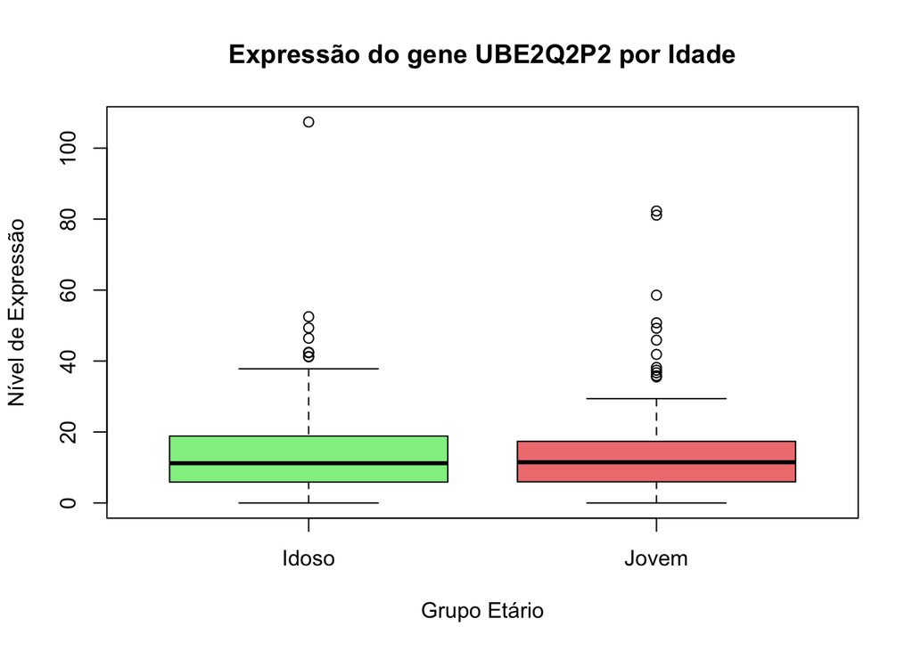

```
## -- replacing outliers and refitting for 2867 genes
## -- DESeq argument 'minReplicatesForReplace' = 7
## -- original counts are preserved in counts(dds)
```

```
##
## out of 20111 with nonzero total read count
## adjusted p-value < 0.1
## LFC > 0 (up)       : 1171, 5.8%
## LFC < 0 (down)     : 1580, 7.9%
## outliers [1]       : 0, 0%
## low counts [2]     : 392, 1.9%
## (mean count < 0)
## [1] see 'cooksCutoff' argument of ?results
## [2] see 'independentFiltering' argument of ?results
```

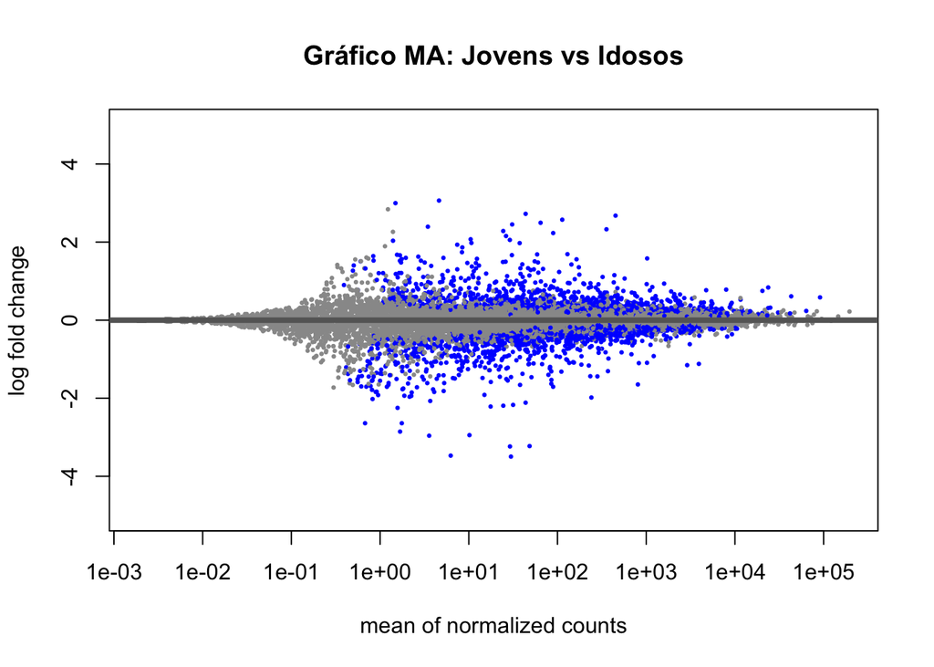